# Lab session 1 - Bayesian Statistics

April, 04 2019

# Poisson model

**1** A family of distributions $\mathcal F=\{p(y|\theta):\theta\in\Theta\subset\mathbb R^d\}$ is an $\textit{exponential family}$ if its elements can be written as

$$p(y|\theta) = f(y)g(\theta) e^{\phi(\theta)^Tu(y)}$$
where

- $f:\mathbb R\rightarrow \mathbb R$
- $g:\mathbb R^d\rightarrow \mathbb R$
- $\phi:\mathbb R^d\rightarrow \mathbb R^d$
- $u:\mathbb R^d\rightarrow \mathbb R^d$

are known functions. Prove that the Poisson distribution, with PMF

$$p(y|\theta) = \frac{\theta^{y}e^{-\theta}}{y!}, \quad \text{for } y=0,1,2,\ldots$$

with $\theta>0$, is an exponential family distribution.

| **Sol** |
| --- |
| We can write the pdf as |
| $$p(y\|\theta) = \frac{1}{y!} e^{y \log \theta -\theta}$$ Thus, $f(y)=\frac{1}{y!}$, $g(\theta)=e^{-\theta}$, $\phi(\theta)=\log(\theta)$, $u(y)=y$. |

**2** Show that the Gamma prior $\Gamma(\alpha,\beta)$ on $\theta$ with pdf

$$\pi(\theta)= \frac{\beta^{\alpha}}{\Gamma(\alpha)}\theta^{\alpha-1}e^{-\beta\theta}, \quad \text{for } \theta > 0$$

with $\alpha >0$ and $\beta> 0$, is a conjugate prior for the Poisson model and find the parameters of the posterior distribution $\pi(\theta|\textbf{y})$.

| **Sol** |
| --- |
| Conjugacy requires the posterior distribution $\pi(\theta\|\mathbf{y})$ and the prior dist ribution $\pi(\theta)$ to be in the same family. |
| The posterior in our case is $$\theta\|\mathbf{y} \sim \Gamma\left(\sum_{i=1}^n y_i+\alpha, n+\beta\right)$$ |

**3** Compute the Jeffreys’ prior for the parameter $\theta$. The Jeffreys’ prior in the univariate case is defined as

$$\pi_J(\theta) \propto \sqrt{\mathcal I(\theta)}$$
with
$$\mathcal I(\theta) = - \mathbb{E}\left[\frac{d^2 \log p(\mathbf{y}|\theta)}{d \theta^2}\right]$$
Is it a proper distribution? Compute the posterior distribution.

| **Sol** The Jeffreys’ prior is |
| --- |
| $$\pi_J(\theta) \propto \theta^{-1/2}$$ |
| which is an improper distribution. But the posterior distribution is proper and in particular |
| $$\pi(\theta\|\mathbf{y}) \sim \Gamma\left(\sum_{i=1}^n y_i+.5,n\right)$$ |

**4-R** Simulate three random samples of size 20, 100 and 1000 from a Poisson distribution with parameter $\theta=.5$.

Assume a prior gamma distribution for the parameter $\theta$ with the following four sets of hyperparameters:

- $\alpha_1 = 1 \quad \beta_1 = .5$
- $\alpha_2 = 1 \quad \beta_2 = 2$
- $\alpha_3 = 1 \quad \beta_3 = 10$
- $\alpha_4 = 2 \quad \beta_4 = 2$
1. Plot the four prior distributions on the same graph, then add the Jeffreys’ prior.

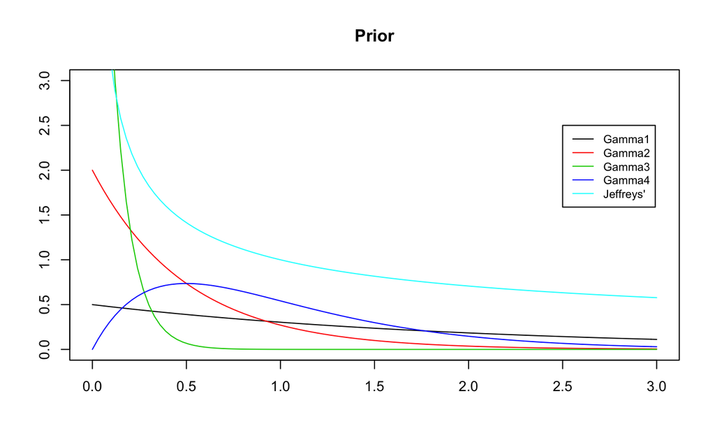

```r
set.seed(123)

y20   <- rpois(20, .5)
y100  <- rpois(100, .5)
y1000 <- rpois(1000, .5)

a <- c(1, 1, 1, 2, .5)
b <- c(.5, 2, 10, 2, 0)

priordist <- function(theta, k){
    if(k==5){return(1/sqrt(theta))}
    return(dgamma(theta, a[k], b[k]))
}

xl <- c(0,3)
yl <- c(0,3)

plot(c(),c(),xlim=xl,ylim=yl,main="Prior",xlab="",ylab="")
for(k in 1:5) curve(priordist(x,k), add=T, col=k)
legend(2.5, 2.5,
       legend=c("Gamma1", "Gamma2",
                "Gamma3", "Gamma4",
                "Jeffreys'"),
       col=c(1:5), lty=1, cex=0.8)
```

2. For each simulated dataset, plot on the same graph the five posterior distributions.

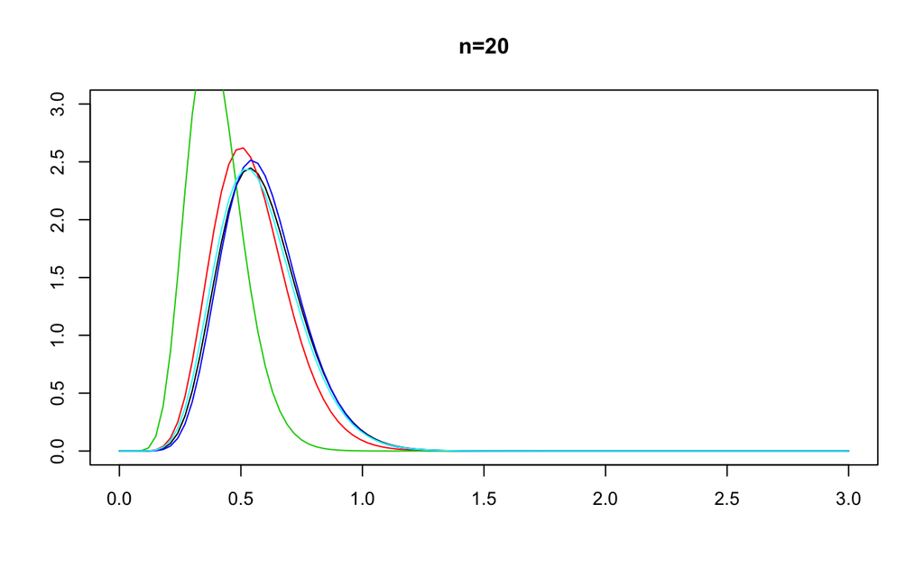

```r
postdist <- function(theta,y,k){
  return(dgamma(theta,a[k]+sum(y),b[k]+length(y)))
}

plot(c(),c(),xlim=xl,ylim=yl,main="n=20",xlab="",ylab="")
for(k in 1:5) curve(postdist(x,y20,k), add=T, col=k)
```

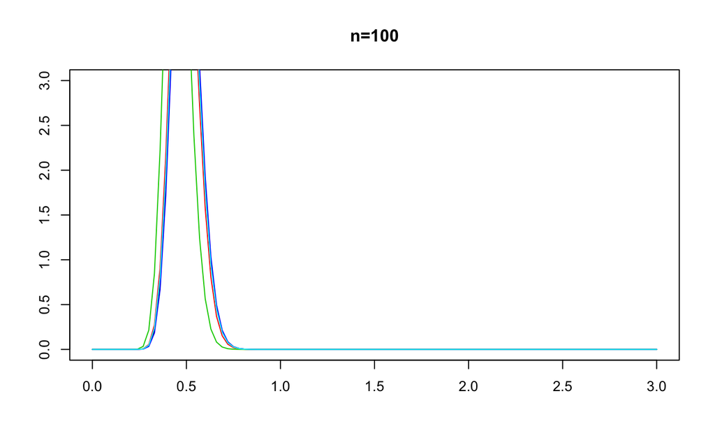

```r
plot(c(),c(),xlim=xl,ylim=yl,main="n=100",xlab="",ylab="")
for(k in 1:5) curve(postdist(x,y100,k), add=T, col=k)
```

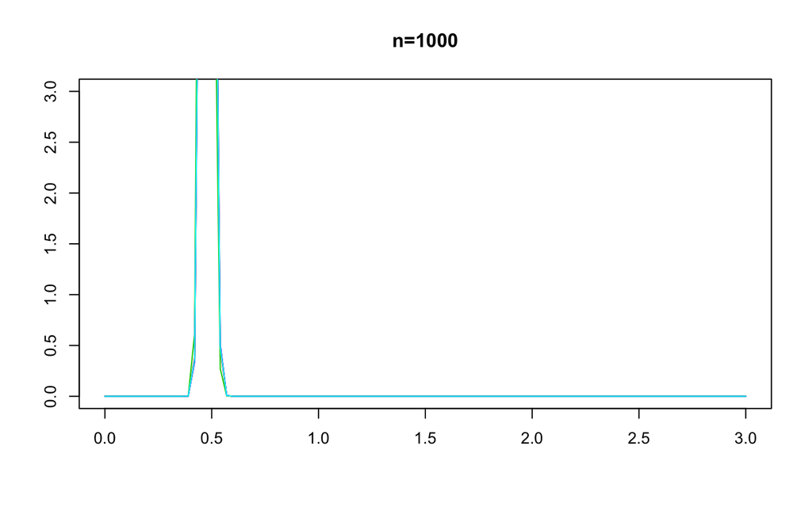

```r
plot(c(),c(),xlim=xl,ylim=yl,main="n=1000",xlab="",ylab="")
for(k in 1:5) curve(postdist(x,y1000,k), add=T, col=k)
```

3. Find the posterior expectations and the maxima a posteriori (MAP) of $\theta$.

```r
## posterior expectations
(a+sum(y20))/(b+20)
```

```
## [1] 0.5853659 0.5454545 0.4000000 0.5909091 0.5750000
```

```r
(a+sum(y100))/(b+100)
```

```
## [1] 0.4975124 0.4901961 0.4545455 0.5000000 0.4950000
```

```r
(a+sum(y1000))/(b+1000)
```

```
## [1] 0.4797601 0.4790419 0.4752475 0.4800399 0.4795000
```

```r
##MAP
(a+sum(y20)-1)/(b+20)
```

```
## [1] 0.5365854 0.5000000 0.3666667 0.5454545 0.5250000
```

```r
(a+sum(y100)-1)/(b+100)
```

```
## [1] 0.4875622 0.4803922 0.4454545 0.4901961 0.4850000
```

```r
(a+sum(y1000)-1)/(b+1000)
```

```
## [1] 0.4787606 0.4780439 0.4742574 0.4790419 0.4785000
```

4. Comment on plots and estimations.
5. Construct the 95% credible intervals, equi-tails and highest posterior density (HPD), for the three datasets using the Jeffreys’ prior.

```r
qgamma(c(.025,.975),-.5+sum(y20),20)
```

```
## [1] 0.2570724 0.8869719
```

```r
qgamma(c(.025,.975),-.5+sum(y100),100)
```

```
## [1] 0.3582076 0.6307072
```

```r
qgamma(c(.025,.975),-.5+sum(y1000),1000)
```

```
## [1] 0.4365814 0.5223127
```

```r
hpd<-function(y,p){
dy<-density(y)
md<-dy$x[dy$y==max(dy$y)]
py<-dy$y/sum(dy$y)
pys<--sort(-py)
ct<-min(pys[cumsum(pys)< p])
list(hpdr=range(dy$x[py>=ct]),mode=md)
}

hpd(rgamma(1000,-.5+sum(y20),20),.95)
```

```
## $hpdr
## [1] 0.2171316 0.8405557
##
## $mode
## [1] 0.4906497
```

```r
hpd(rgamma(1000,-.5+sum(y100),100),.95)
```

```
## $hpdr
## [1] 0.3434509 0.6333469
##
## $mode
## [1] 0.4596539
```

```r
hpd(rgamma(1000,-.5+sum(y1000),1000),.95)
```

```
## $hpdr
## [1] 0.4365653 0.5209245
##
## $mode
## [1] 0.4770072
```